# LONDON HOUSING DATASET

This dataset is primarily centered around the housing market of London. It contains a lot of additional relevant data

Monthly average house prices, Yearly number of houses sold and Monthly number of crimes committed

The data used here is from year 1995 to 2019 of each different area This data is available as a CSV file, downloaded from Kaggle.

‘We will analyze this data using the Pandas DataFrame.

Here, random sets of quesitons are given for which we have to find correct results.

This project is for beginners and for those who want to know how we analyze big data with Python.

```python
import pandas as pd
```

```python
df = pd.read_csv("5. London Housing Data.csv")
```

```python
df.head()
```

|  | date | area | average_price | code | houses_sold | no_of_crimes |
| --- | --- | --- | --- | --- | --- | --- |
| 0 | 1/1/1995 | city of london | 91449 | E09000001 | 17.0 | NaN |
| 1 | 2/1/1995 | city of london | 82203 | E09000001 | 7.0 | NaN |
| 2 | 3/1/1995 | city of london | 79121 | E09000001 | 14.0 | NaN |
| 3 | 4/1/1995 | city of london | 77101 | E09000001 | 7.0 | NaN |
| 4 | 5/1/1995 | city of london | 84409 | E09000001 | 10.0 | NaN |

```python
df.count() #It counts the no. of non-null values of each column.
```

```
date             13549
area             13549
average_price    13549
code             13549
houses_sold      13455
no_of_crimes      7439
dtype: int64
```

```python
df.isnull().sum() #It detects the missing values from the dataframe.
```

```
date                0
area                0
average_price       0
code                0
houses_sold        94
no_of_crimes     6110
dtype: int64
```

```python
import seaborn as sns #To import the Seaborn library.
```

```python
import matplotlib.pyplot as plt #To import the Matplotlib library.
```

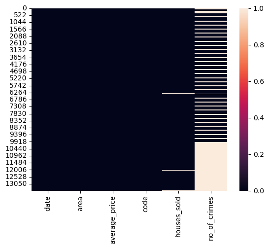

```python
sns.heatmap(df.isnull())
```

(A) Convert the Datatype of ‘Date’ column to Date-Time format.

```python
df.dtypes
```

```
date              object
area              object
average_price      int64
code              object
houses_sold      float64
no_of_crimes     float64
dtype: object
```

```python
df["date"] = pd.to_datetime(df["date"])
```

```python
df.dtypes
```

```
date             datetime64[ns]
area                     object
average_price             int64
code                     object
houses_sold             float64
no_of_crimes            float64
dtype: object
```

(B.1) Add a new column "year" in the dataframe, which contains years only.

```python
df["Year"] = df["date"].dt.year  #extracting year from date column
```

```python
df
```

|  | date | area | average_price | code | houses_sold | no_of_crimes | Year |
| --- | --- | --- | --- | --- | --- | --- | --- |
| 0 | 1995-01-01 | city of london | 91449 | E09000001 | 17.0 | NaN | 1995 |
| 1 | 1995-02-01 | city of london | 82203 | E09000001 | 7.0 | NaN | 1995 |
| 2 | 1995-03-01 | city of london | 79121 | E09000001 | 14.0 | NaN | 1995 |
| 3 | 1995-04-01 | city of london | 77101 | E09000001 | 7.0 | NaN | 1995 |
| 4 | 1995-05-01 | city of london | 84409 | E09000001 | 10.0 | NaN | 1995 |
| ... | ... | ... | ... | ... | ... | ... | ... |
| 13544 | 2019-09-01 | england | 249942 | E92000001 | 64605.0 | NaN | 2019 |
| 13545 | 2019-10-01 | england | 249376 | E92000001 | 68677.0 | NaN | 2019 |
| 13546 | 2019-11-01 | england | 248515 | E92000001 | 67814.0 | NaN | 2019 |
| 13547 | 2019-12-01 | england | 250410 | E92000001 | NaN | NaN | 2019 |
| 13548 | 2020-01-01 | england | 247355 | E92000001 | NaN | NaN | 2020 |

13549 rows × 7 columns

(B.2) Add a new column "month" as 2nd column in the dataframe, which contains month only.

```python
df["Month"] = df["date"].dt.month #Extracting month from date column
df["Year"] = df["date"].dt.year
```

```python
df
```

|  | date | area | average_price | code | houses_sold | no_of_crimes | Year | Month |
| --- | --- | --- | --- | --- | --- | --- | --- | --- |
| 0 | 1995-01-01 | city of london | 91449 | E09000001 | 17.0 | NaN | 1995 | 1 |
| 1 | 1995-02-01 | city of london | 82203 | E09000001 | 7.0 | NaN | 1995 | 2 |
| 2 | 1995-03-01 | city of london | 79121 | E09000001 | 14.0 | NaN | 1995 | 3 |
| 3 | 1995-04-01 | city of london | 77101 | E09000001 | 7.0 | NaN | 1995 | 4 |
| 4 | 1995-05-01 | city of london | 84409 | E09000001 | 10.0 | NaN | 1995 | 5 |
| ... | ... | ... | ... | ... | ... | ... | ... | ... |
| 13544 | 2019-09-01 | england | 249942 | E92000001 | 64605.0 | NaN | 2019 | 9 |
| 13545 | 2019-10-01 | england | 249376 | E92000001 | 68677.0 | NaN | 2019 | 10 |
| 13546 | 2019-11-01 | england | 248515 | E92000001 | 67814.0 | NaN | 2019 | 11 |
| 13547 | 2019-12-01 | england | 250410 | E92000001 | NaN | NaN | 2019 | 12 |
| 13548 | 2020-01-01 | england | 247355 | E92000001 | NaN | NaN | 2020 | 1 |

13549 rows × 8 columns

```python
df.insert(1,"Month2",df["date"].dt.month)  #inserting new column as per requirement of index
```

```python
df
```

|  | date | Month2 | area | average_price | code | houses_sold | no_of_crimes | Year | Month |
| --- | --- | --- | --- | --- | --- | --- | --- | --- | --- |
| 0 | 1995-01-01 | 1 | city of london | 91449 | E09000001 | 17.0 | NaN | 1995 | 1 |
| 1 | 1995-02-01 | 2 | city of london | 82203 | E09000001 | 7.0 | NaN | 1995 | 2 |
| 2 | 1995-03-01 | 3 | city of london | 79121 | E09000001 | 14.0 | NaN | 1995 | 3 |
| 3 | 1995-04-01 | 4 | city of london | 77101 | E09000001 | 7.0 | NaN | 1995 | 4 |
| 4 | 1995-05-01 | 5 | city of london | 84409 | E09000001 | 10.0 | NaN | 1995 | 5 |
| ... | ... | ... | ... | ... | ... | ... | ... | ... | ... |
| 13544 | 2019-09-01 | 9 | england | 249942 | E92000001 | 64605.0 | NaN | 2019 | 9 |
| 13545 | 2019-10-01 | 10 | england | 249376 | E92000001 | 68677.0 | NaN | 2019 | 10 |
| 13546 | 2019-11-01 | 11 | england | 248515 | E92000001 | 67814.0 | NaN | 2019 | 11 |
| 13547 | 2019-12-01 | 12 | england | 250410 | E92000001 | NaN | NaN | 2019 | 12 |
| 13548 | 2020-01-01 | 1 | england | 247355 | E92000001 | NaN | NaN | 2020 | 1 |

13549 rows × 9 columns

(C) Remove the columns ‘year’ and 'month' from the dataframe.

```python
df.drop(["Month","Month2","Year"],axis = 1,inplace = True)
```

```python
df
```

|  | date | area | average_price | code | houses_sold | no_of_crimes |
| --- | --- | --- | --- | --- | --- | --- |
| 0 | 1995-01-01 | city of london | 91449 | E09000001 | 17.0 | NaN |
| 1 | 1995-02-01 | city of london | 82203 | E09000001 | 7.0 | NaN |
| 2 | 1995-03-01 | city of london | 79121 | E09000001 | 14.0 | NaN |
| 3 | 1995-04-01 | city of london | 77101 | E09000001 | 7.0 | NaN |
| 4 | 1995-05-01 | city of london | 84409 | E09000001 | 10.0 | NaN |
| ... | ... | ... | ... | ... | ... | ... |
| 13544 | 2019-09-01 | england | 249942 | E92000001 | 64605.0 | NaN |
| 13545 | 2019-10-01 | england | 249376 | E92000001 | 68677.0 | NaN |
| 13546 | 2019-11-01 | england | 248515 | E92000001 | 67814.0 | NaN |
| 13547 | 2019-12-01 | england | 250410 | E92000001 | NaN | NaN |
| 13548 | 2020-01-01 | england | 247355 | E92000001 | NaN | NaN |

13549 rows × 6 columns

(D) Show all the records where 'No. of Crimes' is 0. And, how many such records are there ?

```python
df[df["no_of_crimes"]==0] #filtering
```

|  | date | area | average_price | code | houses_sold | no_of_crimes |
| --- | --- | --- | --- | --- | --- | --- |
| 72 | 2001-01-01 | city of london | 284262 | E09000001 | 24.0 | 0.0 |
| 73 | 2001-02-01 | city of london | 198137 | E09000001 | 37.0 | 0.0 |
| 74 | 2001-03-01 | city of london | 189033 | E09000001 | 44.0 | 0.0 |
| 75 | 2001-04-01 | city of london | 205494 | E09000001 | 38.0 | 0.0 |
| 76 | 2001-05-01 | city of london | 223459 | E09000001 | 30.0 | 0.0 |
| ... | ... | ... | ... | ... | ... | ... |
| 178 | 2009-11-01 | city of london | 397909 | E09000001 | 11.0 | 0.0 |
| 179 | 2009-12-01 | city of london | 411955 | E09000001 | 16.0 | 0.0 |
| 180 | 2010-01-01 | city of london | 464436 | E09000001 | 20.0 | 0.0 |
| 181 | 2010-02-01 | city of london | 490525 | E09000001 | 9.0 | 0.0 |
| 182 | 2010-03-01 | city of london | 498241 | E09000001 | 15.0 | 0.0 |

104 rows × 6 columns

```python
len(df[df["no_of_crimes"]==0]) #using length function
```

```
104
```

(E) What is the maximum & minimum ‘average_price' per year in england ?

```python
df1 = df[df["area"] == "england"]
```

```python
df1.groupby(df1["date"].dt.year).average_price.max()
```

```
date
1995     53901
1996     55755
1997     61564
1998     65743
1999     75071
2000     84191
2001     95992
2002    119982
2003    138985
2004    160330
2005    167244
2006    182031
2007    194764
2008    191750
2009    174136
2010    180807
2011    177335
2012    180129
2013    188544
2014    203639
2015    219582
2016    231922
2017    242628
2018    248620
2019    250410
2020    247355
Name: average_price, dtype: int64
```

```python
df1.groupby(df1["date"].dt.year).average_price.min()
```

```
date
1995     52788
1996     52333
1997     55789
1998     61659
1999     65522
2000     75219
2001     84245
2002     96215
2003    121610
2004    139719
2005    158572
2006    166544
2007    181824
2008    165795
2009    159340
2010    174458
2011    173046
2012    174161
2013    176816
2014    188265
2015    202856
2016    220361
2017    231593
2018    240428
2019    243281
2020    247355
Name: average_price, dtype: int64
```

(F) What is the Maximum & Minimum No. of Crimes recorded per area ?

```python
df.groupby("area").no_of_crimes.max().dropna().sort_values(ascending = False).head(10)
```

```
area
westminster      7461.0
lambeth          4701.0
camden           4558.0
southwark        3821.0
newham           3668.0
hackney          3466.0
ealing           3401.0
islington        3384.0
tower hamlets    3316.0
croydon          3263.0
Name: no_of_crimes, dtype: float64
```

```python
df.groupby("area").no_of_crimes.min().dropna().sort_values().head(10)
```

```
area
city of london               0.0
kingston upon thames       692.0
richmond upon thames       700.0
sutton                     787.0
merton                     819.0
bexley                     860.0
harrow                     937.0
havering                  1130.0
barking and dagenham      1217.0
hammersmith and fulham    1323.0
Name: no_of_crimes, dtype: float64
```

(G) Show the total count of records of each area, where average price is less than 100000.

```python
df[df["average_price"] < 100000].area.value_counts()
```

```
north east              112
north west              111
yorks and the humber    110
east midlands            96
west midlands            94
england                  87
barking and dagenham     85
south west               78
east of england          76
newham                   72
bexley                   64
waltham forest           64
lewisham                 62
havering                 60
south east               59
greenwich                59
croydon                  57
enfield                  54
sutton                   54
hackney                  53
redbridge                52
southwark                48
tower hamlets            47
outer london             46
hillingdon               44
lambeth                  41
hounslow                 41
brent                    40
london                   39
merton                   35
haringey                 33
bromley                  33
inner london             31
ealing                   31
kingston upon thames     30
harrow                   30
wandsworth               26
barnet                   25
islington                19
city of london           11
Name: area, dtype: int64
```